# Clasificación con Random Forest

En este notebook vamos a contruir, paso a paso, una solución de aprendizaje de máquina siguiendo el mismo ciclo de trabajo que ya usaste en prácticas anteriores (comprensión del problema, comprensión y preparación de los datos, modelado y evaluación) para el problema de predecir si un vino será calificado como de buena calidad a partir de sus propiedades físico-químicas.

Utilizaremos el mismo conjunto de datos y las mismas decisiones sobre los datos que en el notebook de KNN y SMOTE, pero cambiamos de algoritmo y de estrategia frente al desbalance de clases:

- **Random Forest**, un modelo de ensamble que combina múltiples árboles de decisión construidos sobre diferentes muestras y subconjuntos de variables para obtener una predicción más robusta.
- **`class_weight`**, una estrategia para manejar el desbalance que asigna mayor peso a los errores de la clase minoritaria durante el entrenamiento, sin generar datos sintéticos.

El flujo general es el siguiente:

1. Importar librerías
2. Comprensión del problema
3. Comprensión de los datos
4. Limpieza y preparación de los datos
5. Modelado con Random Forest, sin y con `class_weight`
6. Evaluación
7. Importancia de variables e interpretación
8. Cierre
9. Ejercicios

## 1. Importar librerías

```python
import numpy as np
import pandas as pd
import matplotlib.pyplot as plt

from sklearn.model_selection import train_test_split, StratifiedKFold, GridSearchCV
from sklearn.ensemble import RandomForestClassifier
from sklearn.metrics import classification_report, confusion_matrix, ConfusionMatrixDisplay, f1_score, recall_score, precision_score
```

## 2. Comprensión del problema

Evaluar la calidad de un vino tradicionalmente depende de catadores expertos, un proceso costoso, lento y hasta cierto punto subjetivo. Si pudiéramos predecir con buena precisión la calidad de un vino a partir de mediciones físico-químicas objetivas (acidez, azúcar, alcohol, etc.), una bodega podría usar ese modelo como un filtro de control de calidad rápido y barato, reservando la cata experta para los casos más dudosos.

> En su forma original, este es un problema multiclase, ya que `quality` es una calificación de 0 a 10 otorgada por expertos, con varias categorías posibles. Para esta práctica, lo simplificamos a un problema de **clasificación binaria**. En la Sección 3 transformamos `quality` en "bueno" vs. "no bueno", una decisión nuestra (no una propiedad inherente de los datos) que nos permite enfocarnos en Random Forest y `class_weight` sin la complejidad adicional de un desbalance multiclase.

## 3. Comprensión de los datos

Cargamos el conjunto de vino tinto directamente desde el UCI Machine Learning Repository. Dataset: Cortez, P., Cerdeira, A., Almeida, F., Matos, T., & Reis, J. (2009). Modeling wine preferences by data mining from physicochemical properties. Decision Support Systems, 47(4), 547–553.

```python
url = "https://archive.ics.uci.edu/ml/machine-learning-databases/wine-quality/winequality-red.csv"
df = pd.read_csv(url, sep=';')
df.head()
```

|  | fixed acidity | volatile acidity | citric acid | residual sugar | chlorides | free sulfur dioxide | total sulfur dioxide | density | pH | sulphates | alcohol | quality |
| --- | --- | --- | --- | --- | --- | --- | --- | --- | --- | --- | --- | --- |
| 0 | 7.4 | 0.70 | 0.00 | 1.9 | 0.076 | 11.0 | 34.0 | 0.9978 | 3.51 | 0.56 | 9.4 | 5 |
| 1 | 7.8 | 0.88 | 0.00 | 2.6 | 0.098 | 25.0 | 67.0 | 0.9968 | 3.20 | 0.68 | 9.8 | 5 |
| 2 | 7.8 | 0.76 | 0.04 | 2.3 | 0.092 | 15.0 | 54.0 | 0.9970 | 3.26 | 0.65 | 9.8 | 5 |
| 3 | 11.2 | 0.28 | 0.56 | 1.9 | 0.075 | 17.0 | 60.0 | 0.9980 | 3.16 | 0.58 | 9.8 | 6 |
| 4 | 7.4 | 0.70 | 0.00 | 1.9 | 0.076 | 11.0 | 34.0 | 0.9978 | 3.51 | 0.56 | 9.4 | 5 |

```python
data = df.copy()
```

```python
data.shape
```

```
(1599, 12)
```

A continuación, el diccionario de datos completo.

#### Diccionario de datos

| Variable | Tipo | Descripción |
| --- | --- | --- |
| `fixed acidity` | Numérica (continua) | Ácidos no volátiles (principalmente tartárico) que no se evaporan fácilmente, en g/dm³ |
| `volatile acidity` | Numérica (continua) | Ácidos volátiles (principalmente acético) en g/dm³; en niveles altos genera un sabor a vinagre desagradable |
| `citric acid` | Numérica (continua) | Aporta frescura y sabor al vino, en g/dm³; se encuentra en pequeñas cantidades |
| `residual sugar` | Numérica (continua) | Azúcar remanente después de la fermentación, en g/dm³ |
| `chlorides` | Numérica (continua) | Cantidad de sal en el vino, en g/dm³ |
| `free sulfur dioxide` | Numérica (continua) | Forma libre de SO₂ en mg/dm³; previene el crecimiento microbiano y la oxidación |
| `total sulfur dioxide` | Numérica (continua) | Suma de SO₂ libre y ligado en mg/dm³; en concentraciones altas es perceptible en el sabor y olor |
| `density` | Numérica (continua) | Densidad del vino en g/cm³, relacionada con el contenido de alcohol y azúcar |
| `pH` | Numérica (continua) | Nivel de acidez/alcalinidad, en una escala de 0 (muy ácido) a 14 (muy básico) |
| `sulphates` | Numérica (continua) | Aditivo (sulfato de potasio) en g/dm³ que contribuye a los niveles de SO₂; actúa como antimicrobiano y antioxidante |
| `alcohol` | Numérica (continua) | Porcentaje de contenido de alcohol (% vol.) |
| `quality` | Numérica (discreta, ordinal) | **Variable objetivo.** Mediana de al menos 3 evaluaciones sensoriales de catadores expertos, en una escala de 0 a 10 |

El conjunto tiene 1.599 vinos y 11 variables físico-químicas, más la variable objetivo `quality`.

#### 3.1 Conociendo más la variable objetivo: ¿Qué es un vino bueno?

`quality` es un puntaje ordinal. Para plantear un problema de clasificación binaria, se adopta un criterio frecuente en la literatura sobre este conjunto de datos, donde un vino se considera bueno si `quality >= 7` y no bueno en caso contrario. Este umbral permite distinguir los vinos con calificaciones altas y genera un desbalance de clases útil para analizar posteriormente estrategias como `class_weight`.

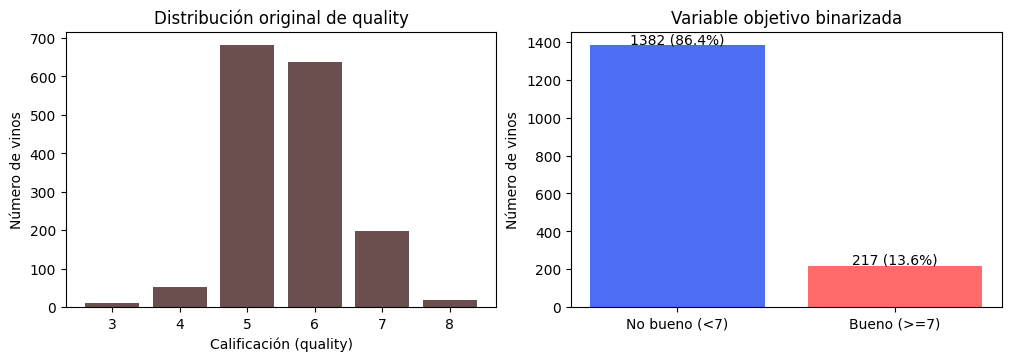

```python
fig, ax = plt.subplots(1, 2, figsize=(10, 3.5), constrained_layout=True)

conteo_quality = data['quality'].value_counts().sort_index()
ax[0].bar(conteo_quality.index.astype(str), conteo_quality.values, color='#6b4f4f')
ax[0].set(xlabel='Calificación (quality)', ylabel='Número de vinos', title='Distribución original de quality')

data['es_bueno'] = (data['quality'] >= 7).astype(int)
conteo_binaria = data['es_bueno'].value_counts().sort_index()
ax[1].bar(['No bueno (<7)', 'Bueno (>=7)'], conteo_binaria.values, color=['#4C6EF5', '#FF6B6B'])
for i, v in enumerate(conteo_binaria.values):
    ax[1].text(i, v + 10, f"{v} ({v/len(df)*100:.1f}%)", ha='center')
ax[1].set(ylabel='Número de vinos', title='Variable objetivo binarizada')

plt.show()
```

**Cómo se lee:** la mayoría de los vinos se concentran en las calificaciones intermedias (5 y 6); muy pocos llegan a 7 u 8. Al binarizar, la clase "bueno" representa solo ~13.6% de los vinos, un desbalance real (no fabricado por nosotros), consecuencia de que los catadores expertos rara vez califican un vino como sobresaliente.

#### Fuga de datos

`quality` es la fuente directa de `es_bueno`, debe excluirse de las variables predictoras.

### 4. Limpieza y preparación de los datos.

En este conjunto de datos el único problema son las filas duplicadas (¿puedes verificar las otras dimensiones de calidad?)

```python
n_duplicados = data.duplicated().sum()
print(f"Filas exactamente duplicadas: {n_duplicados} ({n_duplicados/len(data)*100:.1f}% del total)")
```

```
Filas exactamente duplicadas: 240 (15.0% del total)
```

~15% de las filas eran duplicados exactos. Los eliminamos antes de particionar en entrenamiento y prueba, precisamente para que ninguna copia de una misma observación pueda quedar en ambos conjuntos a la vez.

```python
data = data.drop_duplicates().reset_index(drop=True)
print(f"Filas después de eliminar duplicados: {len(data)}")
```

```
Filas después de eliminar duplicados: 1359
```

RandomForest no depende de distancias. Cada árbol divide los datos comparando una variable a la vez con un umbral, por lo que la escala de las variables no afecta estas decisiones. Por esta razón, en este notebook no es necesario escalar las variables.

Separamos variables predictoras y objetivo, y particionamos en entrenamiento y prueba de forma estratificada (para preservar la proporción ~86/14 en ambos conjuntos).

```python
X = data.drop(columns=['quality', 'es_bueno'])
y = data['es_bueno']

X_train, X_test, y_train, y_test = train_test_split(X, y, test_size=0.25, stratify=y, random_state=42)

print(f"Entrenamiento: {len(X_train)} vinos ({y_train.mean()*100:.1f}% buenos)")
print(f"Prueba:        {len(X_test)} vinos ({y_test.mean()*100:.1f}% buenos)")
```

```
Entrenamiento: 1019 vinos (13.5% buenos)
Prueba:        340 vinos (13.5% buenos)
```

## 5. Modelado

### 5.1 Modelado con Random Forest, sin manejo de desbalance

Buscamos los mejores hiperparámetros con `GridSearchCV` directamente sobre `RandomForestClassifier` (sin `Pipeline`, ya que no hay ningún paso de preprocesamiento que aplicar). El grid se limita a tres decisiones: cuántos árboles construir (`n_estimators`), qué tan profundo puede crecer cada árbol (`max_depth`) y cuántas observaciones mínimas debe tener una hoja (`min_samples_leaf`).

Por ahora, dejamos `class_weight=None` (el valor por defecto): cada observación pesa igual, sin importar su clase.

```python
param_grid = {
    'n_estimators': [100, 200, 300],
    'max_depth': [4, 6, 10],
    'min_samples_leaf': [1, 3, 5],
}

cv = StratifiedKFold(n_splits=5, shuffle=True, random_state=42)

modelo_rf = RandomForestClassifier(random_state=42, class_weight=None)

rf_grid = GridSearchCV(
    estimator=modelo_rf,
    param_grid=param_grid,
    cv=cv,
    scoring='f1_macro',
    n_jobs=-1
)
rf_grid.fit(X_train, y_train)

print("Mejores hiperparámetros:", rf_grid.best_params_)
print(f"F1-macro en validación cruzada: {rf_grid.best_score_:.3f}")

best_rf = rf_grid.best_estimator_
```

```
Mejores hiperparámetros: {'max_depth': 6, 'min_samples_leaf': 1, 'n_estimators': 200}
F1-macro en validación cruzada: 0.682
```

Optimizamos `f1_macro` porque, con un desbalance de ~86/14, un modelo que prediga siempre "no bueno" tendría ~86% de exactitud sin aprender nada útil. `f1_macro` promedia el F1 de ambas clases por igual, penalizando que el modelo ignore la clase minoritaria.

Veamos el rendimiento sobre train:

```
              precision    recall  f1-score   support

    No bueno       0.95      1.00      0.98       881
       Bueno       1.00      0.69      0.82       138

    accuracy                           0.96      1019
   macro avg       0.98      0.84      0.90      1019
weighted avg       0.96      0.96      0.95      1019
```

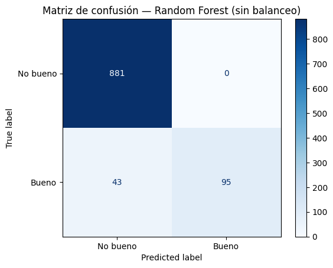

```python
y_pred_rf = best_rf.predict(X_train)
print(classification_report(y_train, y_pred_rf, target_names=['No bueno', 'Bueno'], zero_division=0))

ConfusionMatrixDisplay.from_predictions(y_train, y_pred_rf, display_labels=['No bueno', 'Bueno'], cmap='Blues')
plt.title('Matriz de confusión — Random Forest (sin balanceo)')
plt.show()
```

### 5.2 Modelado con Random Forest y `class_weight`

A diferencia de SMOTE (que genera observaciones sintéticas de la clase minoritaria antes de entrenar), `class_weight` no toca los datos sino que penaliza más el error de clasificación sobre la clase minoritaria *durante* el entrenamiento, ajustando internamente cuánto "cuesta" equivocarse en cada clase. `'balanced'` pondera cada clase de forma inversamente proporcional a su frecuencia; `'balanced_subsample'` hace lo mismo pero recalculando los pesos en cada submuestra bootstrap de cada árbol (una opción exclusiva de Random Forest, al ser un ensamble).

En lugar de fijar un valor, incluimos `class_weight` como un hiperparámetro más dentro del `GridSearchCV`, para que la validación cruzada decida cuál de las dos variantes conviene más.

> **Ejercicio:** antes de continuar, explica con tus propias palabras por qué `class_weight` no requiere ningún cuidado especial dentro de la validación cruzada (a diferencia de SMOTE, que sí exigía ir dentro del pipeline). ¿Qué diferencia fundamental entre ambas estrategias explica esto?

```python
param_grid_cw = {
    'n_estimators': [100, 200, 300],
    'max_depth': [4, 6, 10],
    'min_samples_leaf': [1, 3, 5],
    'class_weight': ['balanced', 'balanced_subsample'],
}

modelo_rfcw = RandomForestClassifier(random_state=42)

rf_cw_grid = GridSearchCV(
    estimator=modelo_rfcw,
    param_grid=param_grid_cw,
    cv=cv,
    scoring='f1_macro',
    n_jobs=-1
)
rf_cw_grid.fit(X_train, y_train)

print("Mejores hiperparámetros:", rf_cw_grid.best_params_)
print(f"F1-macro en validación cruzada: {rf_cw_grid.best_score_:.3f}")

best_rf_cw = rf_cw_grid.best_estimator_
```

```
Mejores hiperparámetros: {'class_weight': 'balanced_subsample', 'max_depth': 6, 'min_samples_leaf': 3, 'n_estimators': 300}
F1-macro en validación cruzada: 0.737
```

Ahora, veamos el rendimiento sobre train:

```
              precision    recall  f1-score   support

    No bueno       0.99      0.92      0.95       881
       Bueno       0.65      0.93      0.77       138

    accuracy                           0.92      1019
   macro avg       0.82      0.93      0.86      1019
weighted avg       0.94      0.92      0.93      1019
```

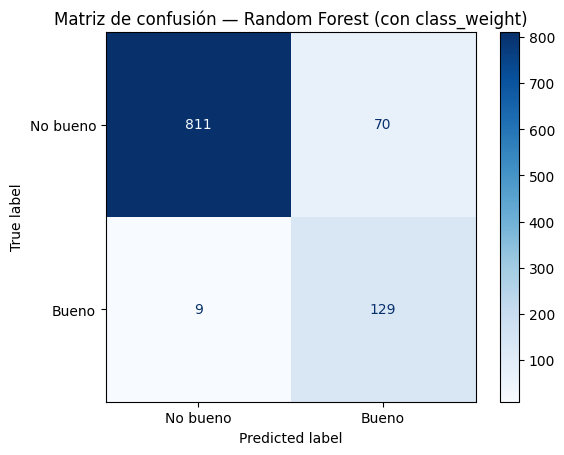

```python
y_pred_rf_cw = best_rf_cw.predict(X_train)
print(classification_report(y_train, y_pred_rf_cw, target_names=['No bueno', 'Bueno'], zero_division=0))

ConfusionMatrixDisplay.from_predictions(y_train, y_pred_rf_cw, display_labels=['No bueno', 'Bueno'], cmap='Blues')
plt.title('Matriz de confusión — Random Forest (con class_weight)')
plt.show()
```

## 6. Evaluación y comparación

Con ambos modelos ya construidos, este es el único punto del notebook donde tocamos `X_test`, y lo hacemos una sola vez, para los dos modelos a la vez.

```python
y_pred_rf = best_rf.predict(X_test)
y_pred_rf_cw = best_rf_cw.predict(X_test)

print("Random Forest (sin balanceo)")
print(classification_report(y_test, y_pred_rf, target_names=['No bueno', 'Bueno'], zero_division=0))
print("\nRandom Forest (con class_weight)")
print(classification_report(y_test, y_pred_rf_cw, target_names=['No bueno', 'Bueno'], zero_division=0))
```

```
Random Forest (sin balanceo)
              precision    recall  f1-score   support

    No bueno       0.89      0.98      0.93       294
       Bueno       0.63      0.26      0.37        46

    accuracy                           0.88       340
   macro avg       0.76      0.62      0.65       340
weighted avg       0.86      0.88      0.86       340


Random Forest (con class_weight)
              precision    recall  f1-score   support

    No bueno       0.94      0.87      0.91       294
       Bueno       0.46      0.67      0.54        46

    accuracy                           0.85       340
   macro avg       0.70      0.77      0.73       340
weighted avg       0.88      0.85      0.86       340
```

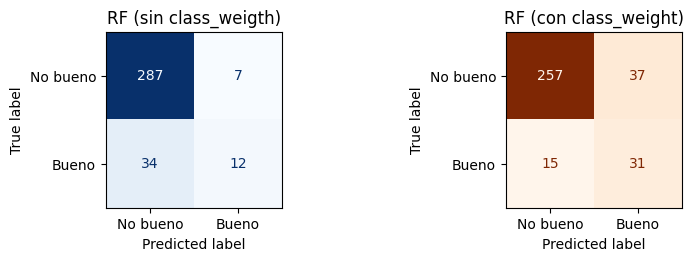

```python
fig, axes = plt.subplots(1, 2, figsize=(8, 2.5), constrained_layout=True)

ConfusionMatrixDisplay.from_predictions(
    y_test, y_pred_rf, display_labels=['No bueno', 'Bueno'], cmap='Blues', ax=axes[0], colorbar=False
)
axes[0].set_title('RF (sin class_weigth)')

ConfusionMatrixDisplay.from_predictions(
    y_test, y_pred_rf_cw, display_labels=['No bueno', 'Bueno'], cmap='Oranges', ax=axes[1], colorbar=False
)
axes[1].set_title('RF (con class_weight)')

plt.show()
```

Compara, lado a lado, el `recall` y la `precisión` de la clase "Bueno" en ambas matrices. En general, `class_weight` mejora el recall (el modelo detecta más vinos buenos) a cambio de una precisión menor (también se equivoca más, marcando como "bueno" algún vino que no lo es). Este es el mismo tipo de trade-off que observamos con SMOTE en el notebook anterior, aunque aquí se logra sin generar ninguna observación sintética.

Ahora, consolidamos las métricas de ambos modelos en una sola tabla y gráfico.

|  | F1-macro | Recall (Bueno) | Precisión (Bueno) |
| --- | --- | --- | --- |
| RF (sin class_weight) | 0.651 | 0.261 | 0.632 |
| RF (con class_weight) | 0.726 | 0.674 | 0.456 |

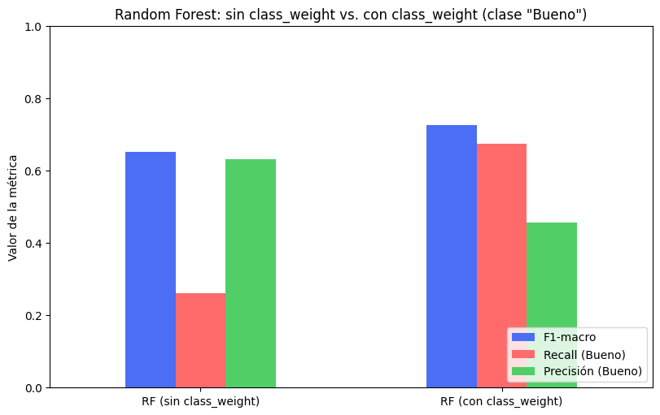

```python
def metricas_modelo(y_true, y_pred):
    return {
        'F1-macro': f1_score(y_true, y_pred, average='macro'),
        'Recall (Bueno)': recall_score(y_true, y_pred, pos_label=1),
        'Precisión (Bueno)': precision_score(y_true, y_pred, pos_label=1, zero_division=0),
    }

resultados = pd.DataFrame({
    'RF (sin class_weight)': metricas_modelo(y_test, y_pred_rf),
    'RF (con class_weight)': metricas_modelo(y_test, y_pred_rf_cw),
}).T

display(resultados.round(3))

fig, ax = plt.subplots(figsize=(8, 5), constrained_layout=True)
resultados.plot(kind='bar', ax=ax, color=['#4C6EF5', '#FF6B6B', '#51CF66'])
ax.set(ylabel='Valor de la métrica', title='Random Forest: sin class_weight vs. con class_weight (clase "Bueno")', ylim=(0, 1))
ax.legend(loc='lower right')
plt.xticks(rotation=0)
plt.show()
```

**Cómo se lee:** esta tabla resume el trade-off que discutimos arriba. Si en tu ejecución `class_weight` mejoró el recall pero no necesariamente el F1-macro (o incluso lo bajó un poco), eso es un resultado legítimo y vale la pena discutirlo: **`class_weight` no garantiza una mejora en todas las métricas**. En general, mejora la capacidad de detectar la clase minoritaria, a cambio de más falsos positivos. Aquí cabe la mismo pregunta sobre los errores ¿qué es más costoso para una bodega, dejar pasar un vino bueno sin identificarlo (falso negativo), o enviar a revisión experta un vino que en realidad no era tan bueno (falso positivo)? La respuesta a esa pregunta de negocio es la que determina si vale la pena usarlo aquí.

## 7. Importancia de variables e interpretación

Random Forest ofrece una medida de interpretación **global**, que es qué tanto contribuye cada variable, en promedio, a reducir la impureza de los nodos a lo largo de todos los árboles del ensamble. Esto se obtiene directamente del modelo entrenado, sin ningún cálculo adicional.

Usamos el modelo con `class_weight`, por ser el que mejor equilibra la detección de la clase minoritaria.

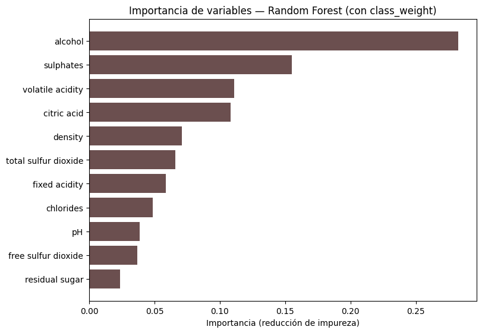

```
alcohol                 0.282315
sulphates               0.155198
volatile acidity        0.110815
citric acid             0.108200
density                 0.070842
total sulfur dioxide    0.066062
fixed acidity           0.058506
chlorides               0.048790
pH                      0.038538
free sulfur dioxide     0.036976
residual sugar          0.023757
dtype: float64
```

```python
importancias = pd.Series(
    best_rf_cw.feature_importances_, index=X.columns
).sort_values(ascending=True)

fig, ax = plt.subplots(figsize=(8, 5.5), constrained_layout=True)
ax.barh(importancias.index, importancias.values, color='#6b4f4f')
ax.set(xlabel='Importancia (reducción de impureza)', title='Importancia de variables — Random Forest (con class_weight)')
plt.show()

importancias.sort_values(ascending=False)
```

**Cómo se interpreta:** `alcohol` es, por amplio margen, la variable más importante, seguida de `sulphates` (sulfatos) y `volatile acidity` (acidez volátil). Esto es consistente con lo que se conoce sobre la percepción sensorial del vino, donde un mayor contenido de alcohol suele asociarse con vinos mejor valorados por los catadores, mientras que una acidez volátil alta genera notas a vinagre que perjudican la calificación (que es exactamente lo que describe el diccionario de datos). Las variables relacionadas con el dióxido de azufre (`free sulfur dioxide`, `total sulfur dioxide`) y el azúcar residual, en cambio, aportan relativamente poco a las decisiones del modelo.

**Una precaución importante:** la importancia de variables de Random Forest mide *asociación predictiva dentro del modelo*, no causalidad. Que `alcohol` sea la variable más importante no prueba que aumentar el alcohol de un vino mejore su calidad, podría haber otras variables correlacionadas (por ejemplo, el proceso de fermentación) que expliquen ambas cosas a la vez.

## 8. Cierre

En este notebook seguimos el ciclo de aprendizaje de máquina sobre el problema de calificación de vinos, pero cambiando de algoritmo y de estrategia frente al desbalance de clases.

**Ideas clave:**

- Random Forest no depende de distancias, por lo que, a diferencia de KNN, no requiere escalar las variables.
- `class_weight` es una alternativa a SMOTE para el desbalance de clases. En lugar de generar observaciones sintéticas antes de entrenar, penaliza el error sobre la clase minoritaria *durante* el entrenamiento. Como no modifica los datos, **no necesita ir dentro de un pipeline especial** dentro de la validación cruzada, no hay riesgo de fuga de información entre folds.
- Al igual que con SMOTE, `class_weight` no garantiza una mejora en todas las métricas. En general, mejora el `recall` de la clase minoritaria a costa de la `precision`. Su conveniencia depende del costo relativo de cada tipo de error en el problema real.
- Random Forest ofrece una interpretación global e inmediata a través de la importancia de variables (`feature_importances_`). Esto facilita explicar el modelo a públicos no técnicos, aunque no debe confundirse con una relación causal.

## 9. Ejercicios

1. Cambia el umbral de "buena calidad" de `quality >= 7` a `quality >= 6`. ¿Cómo cambia el desbalance de clases? ¿Cambian tus conclusiones sobre si `class_weight` ayuda o no?
2. Repite el modelado usando el archivo de vino blanco (`winequality-white.csv`, mismo repositorio UCI, 4,898 muestras). ¿La importancia de variables es similar a la que obtuviste con el vino tinto?
3. En la Sección 5.2, prueba fijar manualmente `class_weight={0: 1, 1: 5}` (dándole 5 veces más peso a la clase "Bueno") en lugar de `'balanced'` o `'balanced_subsample'`. ¿Cómo cambian las métricas de la Sección 6 frente a las que ya obtuviste?
4. Compara la importancia de variables de este notebook con los hiperparámetros que resultaron ganadores en el notebook de árboles y bosques de la práctica anterior. ¿Las variables más relevantes coinciden?